# Regression Model Protocol

Chun-Li Hou

2020-09-23

**Regression modeling processes are theroying, data collection, data cleaning, training set & test set, variable selection (feature selection), advancing by the goodness of fit, checking finalised model assumptions, evaluating with test set (no underfit nor overfit), causation & prediction with the finalised model.**

```r
knitr::opts_chunk$set(echo = TRUE)
if(!require("pacman")) install.packages("pacman")
pacman::p_load(dplyr, ggplot2, GGally, caret, car, lmtest)
options(digits = 3)
theme_set(theme_minimal())
set.seed(123)
```

## 1. Loading & Preprocessing & Exploring

```r
# load
data("mtcars")

# partition dataset (train/test)

# encode categorical data
mtcars$cyl = factor(mtcars$cyl)
mtcars$vs = factor(mtcars$vs)
mtcars$gear = factor(mtcars$gear)
mtcars$carb = factor(mtcars$carb)
mtcars$am = factor(mtcars$am, labels = c("Automatic", "Manual"))

# check others
# 1. missing data
# 2. near zero variance
# 3. mostly NA variable
# 4. identification variable
# 5. correlation matrix (PCA)
```

## 2. Model building

```r
# best fit
init.mod = lm(mpg ~ ., data = mtcars)
best.mod = step(init.mod, direction = "both", trace = FALSE)

# compare other model
# 1. anova(init.mod, best.mod)
# 2. t.test(mpg ~ am, data = mtcars)
```

## 3. Assumption checking

### 1. Outlier

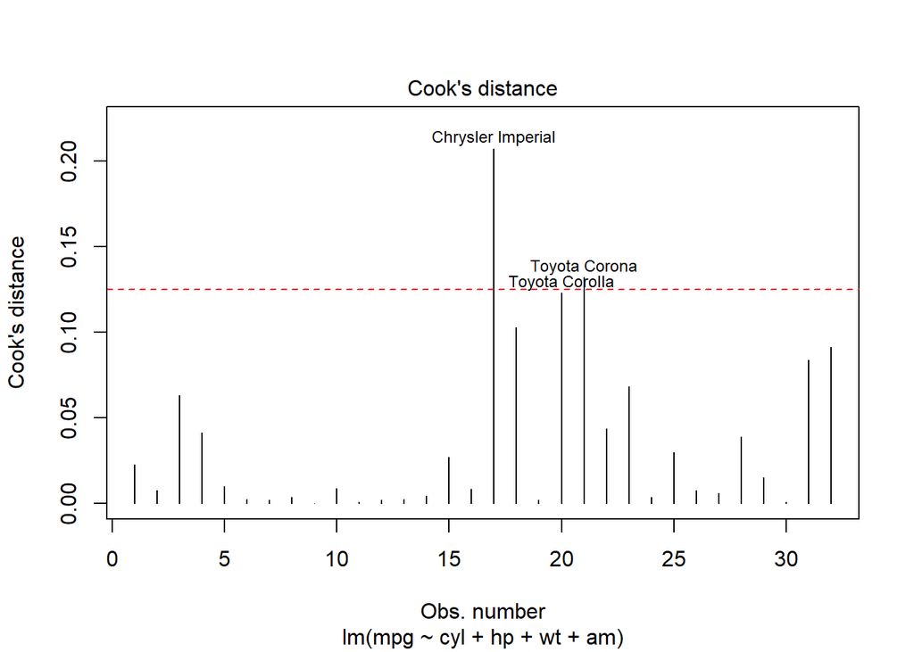

```r
# influence point
plot(best.mod, which = 4)
abline(h = 4/nrow(mtcars), lty = 2, col = "red")
```

```r
influence = c("Chrysler Imperial", "Toyota Corolla", "Toyota Corona")

# leverage point
best.mod %>%
  hatvalues() %>%
  sort() %>%
  tail(3) %>%
  names()
```

```
## [1] "Toyota Corona"       "Lincoln Continental" "Maserati Bora"
```

```r
leverage = c("Toyota Corona", "Lincoln Continental", "Maserati Bora")

# outlier
data.frame(influence, leverage)
```

```
##           influence            leverage
## 1 Chrysler Imperial       Toyota Corona
## 2    Toyota Corolla Lincoln Continental
## 3     Toyota Corona       Maserati Bora
```

- Problem:
  - Outlier will mpact model directly
  - Influence must be outlier, which has extreme value of y so it has the power to move the line
  - Leverage might be outlier, which has extreme value of x so it has possible ability to move the line
- Identification:
  - Influence by cook’s distance with a rule of thumb of 4/n
  - Leverage by the r function
- Solution:
  - Influence must be removed from the dataset
  - Leverage by comparing the model with it and without it

### 2. Collinearity

```r
# rule of thumb
best.mod %>%
  vif() %>%
  as.data.frame() %>%
  mutate("Threshold" = 10^(1/2)) %>%
  mutate("Collinearity" = ifelse(("GVIF^(1/(2*Df))" > "Threshold"),
                                 "Yes", "No"))
```

```
##   GVIF Df GVIF^(1/(2*Df)) Threshold Collinearity
## 1 5.82  2            1.55      3.16           No
## 2 4.70  1            2.17      3.16           No
## 3 4.01  1            2.00      3.16           No
## 4 2.59  1            1.61      3.16           No
```

- Problem:
  - Var more > SE more > CI more > p-value more > non-significant > coefficient close to 0
  - Hard to explain the dedication for corelated variables
  - The more the VIF/VGIF increases, the less reliable the regression model is
- Identification:
  - The rule of thumb for VIF is 10; for GVIF is 3.16
  - If less than threshold, we conclude that there are no collinearity among the indenpendent variables (x) in the model
  - If more than threshold, we conclude that there are collinearity among the indenpendent variables (x) in the model
- Solution:
  - PCA to combine correlated variables together
  - Remove one of the correlated variables
  - Increase data size

### 3. Heteroscedasticity

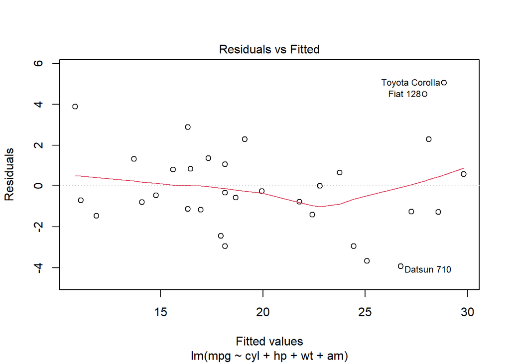

```r
# plot
plot(best.mod, which = 1)
```

```r
# test
bptest(mpg ~ cyl + hp + wt + am, data = mtcars) # similar white test
```

```
##
##  studentized Breusch-Pagan test
##
## data:  mpg ~ cyl + hp + wt + am
## BP = 8, df = 5, p-value = 0.1
```

- Problem:
  - Estimation inefficient
  - SE error > CI wrong
- Identification:
  - Plot seeing for equal spreading of data along the line
  - Test for statisitc inference (H0: Homoscedasticity; H1: Heteroscedasticity)
- Solution:
  - Dependent variable (y) transformation (log/sqrt)
  - Adjust to robust SE
  - Segment data to make each model

### 4. Normality

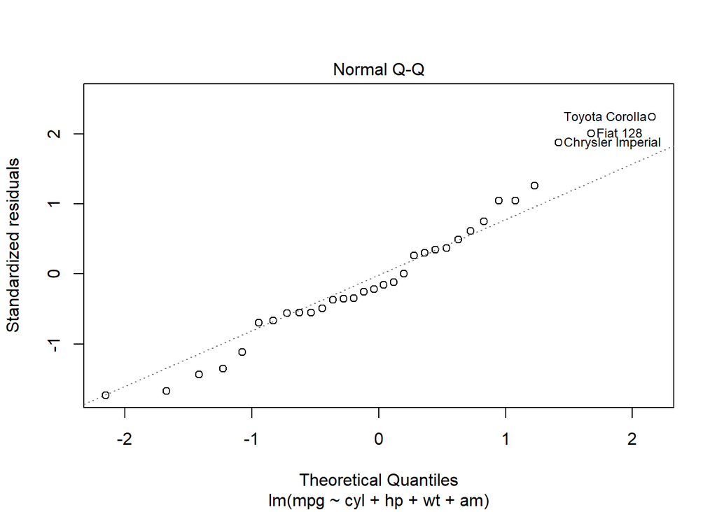

```r
# qq plot
plot(best.mod, which = 2)
```

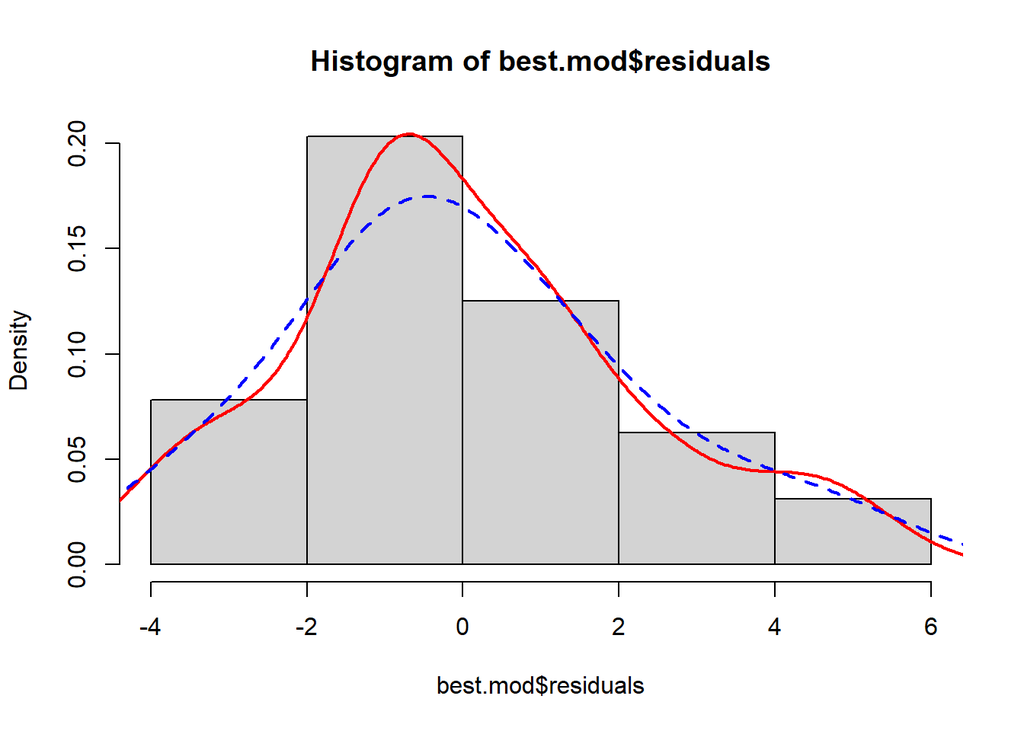

```r
# residual hist
hist(best.mod$residuals, probability = T)
lines(density(best.mod$residuals), lwd = 2, col = "red") # sample distribution
lines(density(best.mod$residuals, adjust = 1.5), lwd = 2, lty = 2, col = "blue") # kernel distribution
```

```r
# check
mean(best.mod$residuals) # close to 0
```

```
## [1] 1.3e-17
```

- Problem:
  - Obey assumption (error distribution is normal; error mean is 0)
- Identification:
  - See QQ plot with the dots all on the line
  - See histogram with an approximate normal distribution
- Solution:
  - Dependent variable (y) transformation (log/sqrt)
  - Relate to the outlier problem

### 5. Autocorrelation

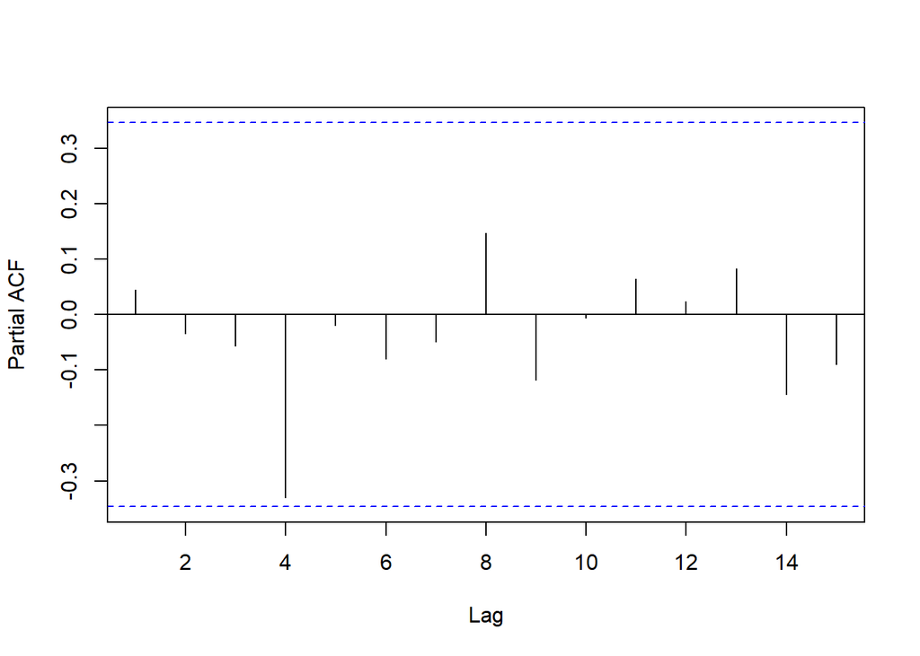

```r
# plot
acf(best.mod$residuals, type = "partial", main = "")
```

- Problem:
  - Obey assumption (error covariance is 0) (no serial correlation)
- Identification:
  - See acf plot with the spike out of the blue line
- Solution:
  - Use time-series process, such as differencing

## 4. Model refining & Analysis & Inference

```r
# remove outlier
# rownames(mtcars) # 17, 20, 21
mtcars.1 = mtcars[-c(17, 20, 21), ]
# rownames(mtcars.1)

# best fit with no outlier
init.mod.1 = lm(mpg ~ ., data = mtcars.1)
best.mod.1 = step(init.mod.1, direction = "both", trace = FALSE)
```

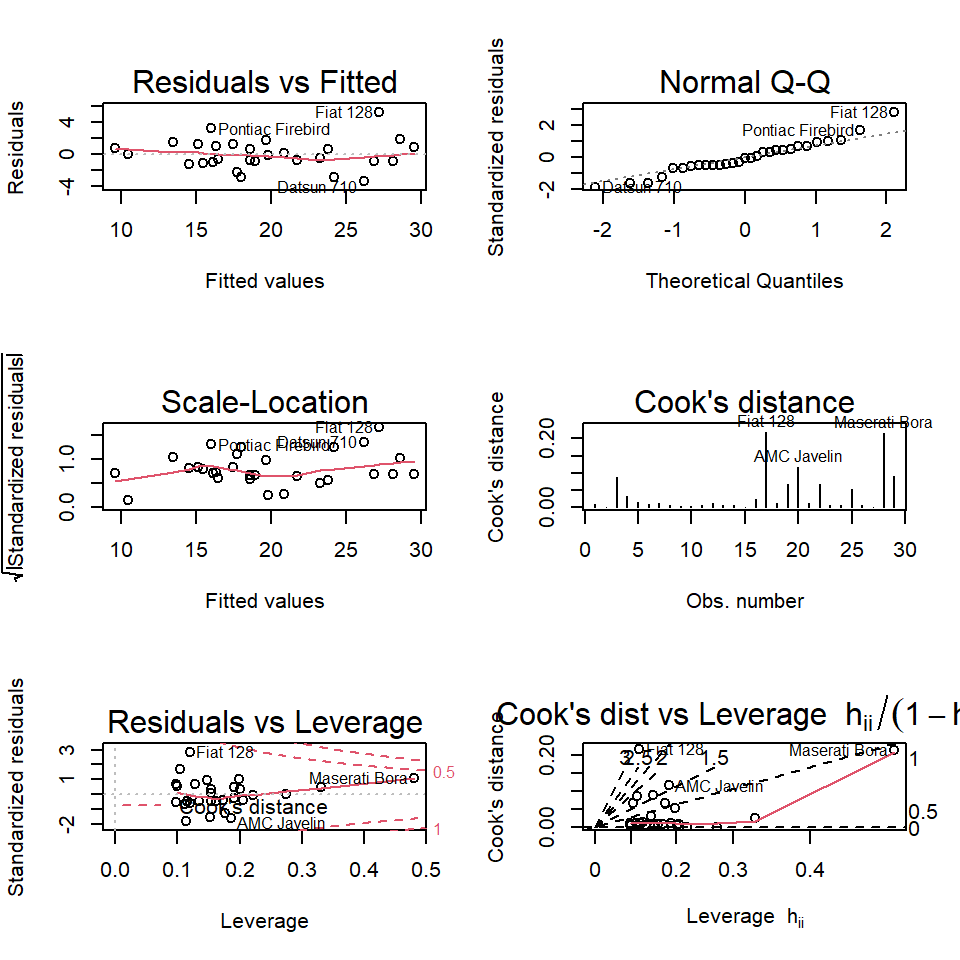

```r
# check again assumption
par(mfrow = c(3, 2)); plot(best.mod.1, which = c(1:6))
```

## 5. Analysis & Inference

```r
summary(best.mod.1)
```

```
##
## Call:
## lm(formula = mpg ~ cyl + hp + wt, data = mtcars.1)
##
## Residuals:
##    Min     1Q Median     3Q    Max
## -3.400 -0.875 -0.107  0.983  5.188
##
## Coefficients:
##             Estimate Std. Error t value Pr(>|t|)
## (Intercept)  36.3793     1.8422   19.75  2.4e-16 ***
## cyl6         -3.0179     1.1829   -2.55    0.018 *
## cyl8         -3.0287     1.8230   -1.66    0.110
## hp           -0.0219     0.0097   -2.26    0.033 *
## wt           -3.5098     0.6417   -5.47  1.3e-05 ***
## ---
## Signif. codes:  0 '***' 0.001 '**' 0.01 '*' 0.05 '.' 0.1 ' ' 1
##
## Residual standard error: 1.96 on 24 degrees of freedom
## Multiple R-squared:  0.898,  Adjusted R-squared:  0.881
## F-statistic: 52.9 on 4 and 24 DF,  p-value: 1.47e-11
```

- Multiple R-squared: 0.898  
  The 89% of the dependent variable (mpg; y) can be explained by the model’s inputs (the independent variables; x).
- Significant coefficient in numeric variable: hp, wt  
  As increasing x by 1 unit, the y would increase/decrease by the coefficient unit.
- Significant coefficient in dummy/indicator/nominal variable: cyl6  
  As for the x in A to B, the difference in y is the coefficient unit.  
  As for the x with A comparing with B, the y would increase/decrease by the coefficient unit.